# project_notes

Christopher Stewart

January 25, 2015

## Introduction

This project addresses a sample machine learning problem: predicting correct / incorrect barbell lifts using personal activity data.

The present analysis uses data from accelerometers on the belt, forearm, arm, and dumbell of 6 participants who performed barbell lifts correctly and incorrectly in 5 different ways.

Initially, we download and inspect the data.

## Loading and Preparing the Data for Exploratory Analysis

```r
require("downloader")
require("caret")
```

```r
require("ggplot2")
require("glmnet")
dataset_url_train <- "https://d396qusza40orc.cloudfront.net/predmachlearn/pml-training.csv"
dataset_url_test <- "https://d396qusza40orc.cloudfront.net/predmachlearn/pml-testing.csv"
download(dataset_url_train, dest = "training.csv")
download(dataset_url_test, dest = "testing.csv")
training = read.csv("training.csv", header = TRUE, na.strings = c("", "NA","#DIV/0!"))
testing = read.csv("testing.csv")
```

## Exploratory Data Analysis and Data Cleaning

A cursory examination of the training data reveals that it begins with an index varible and a series of timestamps. Because these are uninterpretable (timestamps) or not useful for model building (index variables), they are removed at the outset.

We also see that a number of the potential covariates contain negligible amounts of actual data. We continue by removing variables that contain greater than 95% NAs, missing observations or #DIV/0!.

```r
vars2remove <- c(1, 3:5)
varsNA <- which(colMeans(is.na(training)) > .95)
training_clean <- training[, -c(vars2remove, varsNA)]
```

Next, we break the training set up into factor and non-factor variables to facilitate model building.

```r
varsFactor <-which(sapply(training_clean, FUN = class) == "factor")
trainingFactor <- training_clean[, varsFactor]
trainingNoFactor <- as.matrix(training_clean[, -varsFactor])
```

## Model Building

For this multinomial classification problem, we choose the package “glmnet” which fits generalized linear models via penalized maximum likelihood. We choose an elastic net model (by specifying alpha = 0.5 in the function call) in order to achieve a compromise between ridge and lasso penalty approaches.

We first fit a model without cross validation, then plot this initial model for each level of the “classe” variable.

```r
eNet <-glmnet(x = trainingNoFactor, y = trainingFactor[, "classe"],
              family = "multinomial", alpha = 0.5)
print(eNet)
```

```
##
## Call:  glmnet(x = trainingNoFactor, y = trainingFactor[, "classe"],      family = "multinomial", alpha = 0.5)
##
##        Df       %Dev    Lambda
##   [1,]  0 -2.671e-13 3.551e-01
##   [2,]  1  4.698e-03 3.236e-01
##   [3,]  1  9.093e-03 2.948e-01
##   [4,]  1  1.318e-02 2.686e-01
##   [5,]  3  1.953e-02 2.448e-01
##   [6,]  3  2.752e-02 2.230e-01
##   [7,]  3  3.470e-02 2.032e-01
##   [8,]  4  4.130e-02 1.852e-01
##   [9,]  4  4.960e-02 1.687e-01
##  [10,]  6  5.977e-02 1.537e-01
##  [11,]  7  7.134e-02 1.401e-01
```

[output cut: 89 more lines]

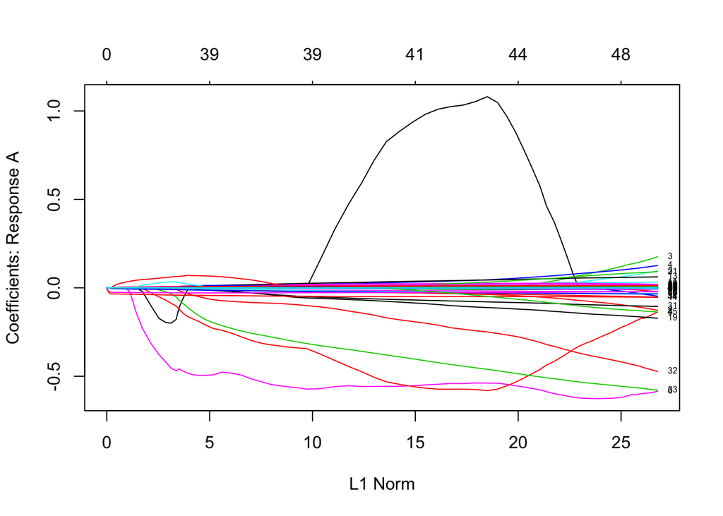

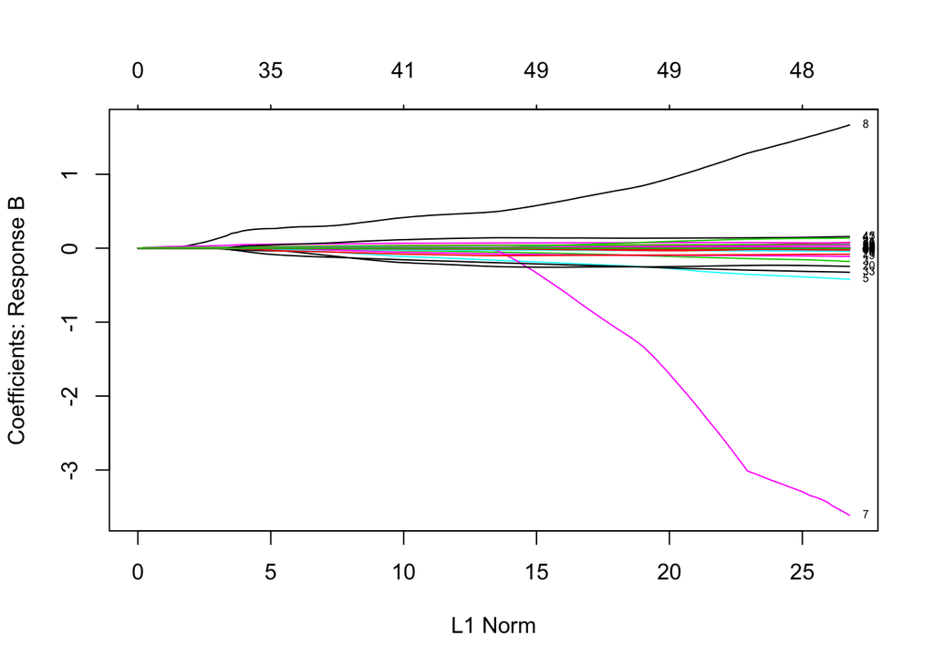

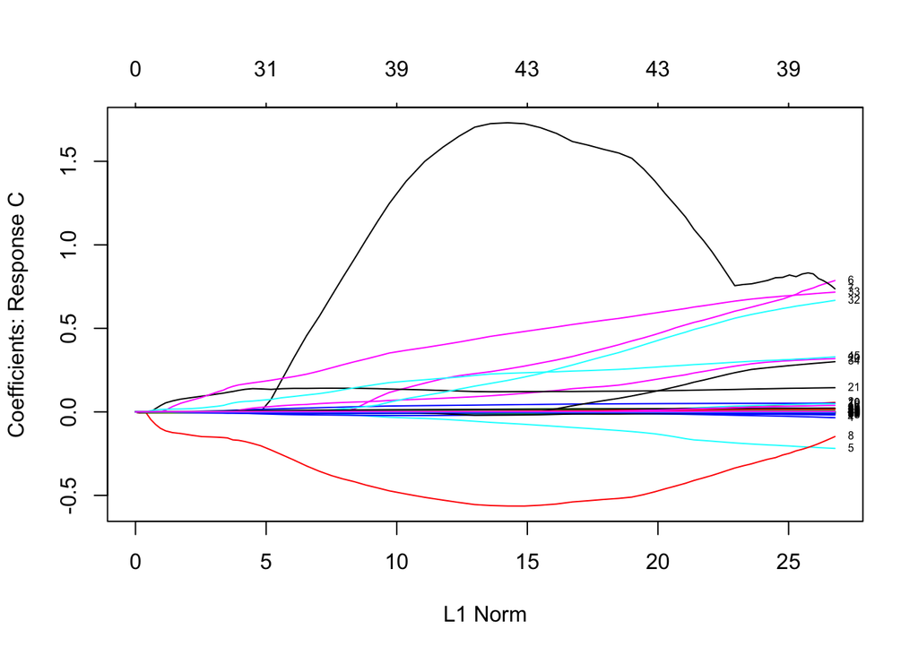

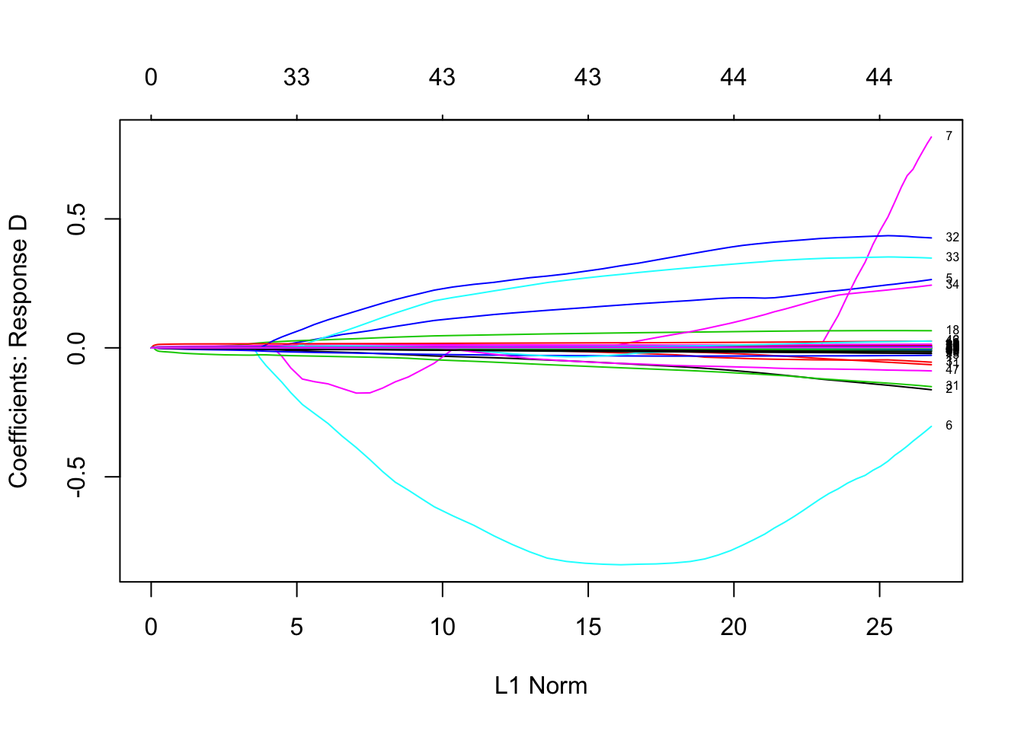

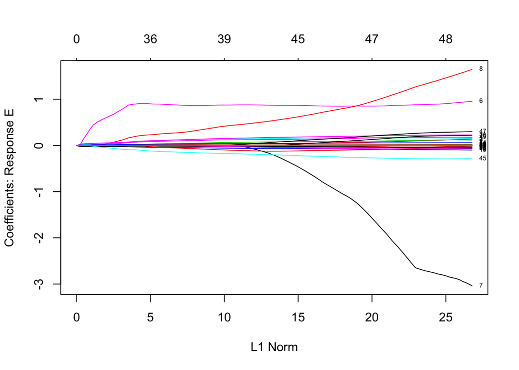

```r
plot (eNet, label = TRUE)
```

In the plot, each curve shows the change in a single variable’s coefficient compared to the whole coefficient vector at values of lambda. Across the levels of the “classe” variable, variables 6, 7 and 8 (gyros_belt_x, gyros_belt_y and gyros_belt_z) appear to have a large impact.

### Cross Validation

In order to choose from the sequence of models with different lambda values provided by glmnet, we perform cross validation using the cv.glmnet function with misclassification error as the criterion for 5-fold procedure.

```r
eNet.cv <-cv.glmnet(x = trainingNoFactor, y = trainingFactor[, "classe"],
family = "multinomial", alpha = 0.5, nfolds = 5, type.measure =
"class")
eNet.cv$lambda.min
```

```
## [1] 5.654657e-05
```

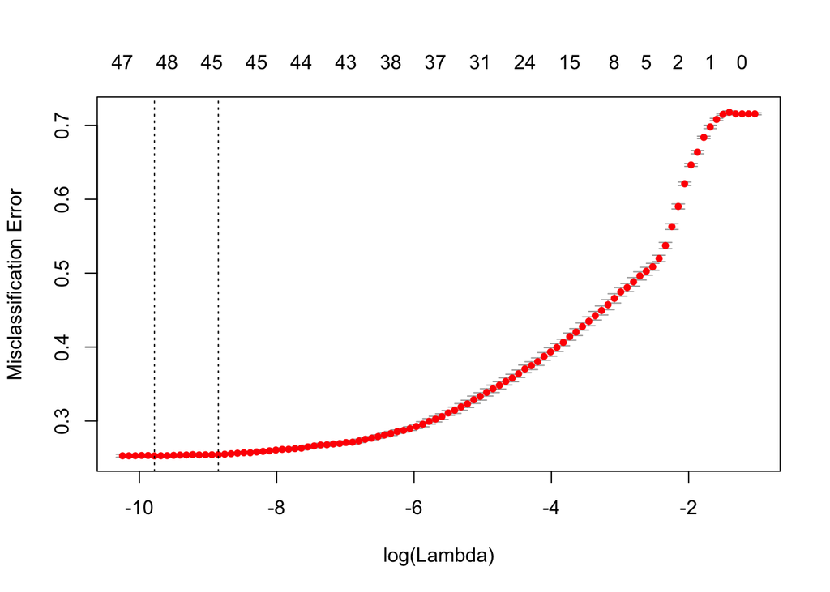

```r
plot(eNet.cv)
```

## Prediction

```r
sample.error <- predict(eNet.cv, newx = trainingNoFactor, type = "class", s = "lambda.min")
confMat <-confusionMatrix(sample.error, trainingFactor$classe)
print(confMat)
```

```
## Confusion Matrix and Statistics
##
##           Reference
## Prediction    A    B    C    D    E
##          A 4865  447  318  217  158
##          B  188 2578  300  149  407
##          C  232  363 2429  382  229
##          D  232  125  205 2314  263
##          E   63  284  170  154 2550
##
## Overall Statistics
##
##                Accuracy : 0.751
##                  95% CI : (0.7449, 0.757)
##     No Information Rate : 0.2844
##     P-Value [Acc > NIR] : < 2.2e-16
##
##                   Kappa : 0.6842
##  Mcnemar's Test P-Value : < 2.2e-16
##
## Statistics by Class:
##
##                      Class: A Class: B Class: C Class: D Class: E
## Sensitivity            0.8719   0.6790   0.7098   0.7195   0.7070
## Specificity            0.9188   0.9340   0.9256   0.9497   0.9581
## Pos Pred Value         0.8102   0.7118   0.6682   0.7372   0.7917
## Neg Pred Value         0.9475   0.9238   0.9379   0.9453   0.9356
## Prevalence             0.2844   0.1935   0.1744   0.1639   0.1838
## Detection Rate         0.2479   0.1314   0.1238   0.1179   0.1300
## Detection Prevalence   0.3060   0.1846   0.1853   0.1600   0.1642
## Balanced Accuracy      0.8953   0.8065   0.8177   0.8346   0.8325
```

At this point, we are ready to predict the classes for the actual testing data. First, we perform the same operations on the testing data that were performed on the training data.

```r
vars2remove <- c(1, 3:5)
varsNA <- which(colMeans(is.na(testing)) > .95)
testing_clean <- testing[, -c(vars2remove, varsNA)]

testing_clean$problem_id <- factor(testing_clean$problem_id)
varsFactor <-which(sapply(testing_clean, FUN = class) == "factor")
testingFactor <- testing_clean[, varsFactor]
testingNoFactor <- data.matrix(testing_clean[, -varsFactor])

answers <- predict(eNet.cv, newx = testingNoFactor, type = "class", s = "lambda.min")
```